# Контрольная работа по прогнозированию временных рядов, вариант 33

Б. Романов

```r
knitr::opts_chunk$set(dev = 'png', warning = FALSE)
# выбор формата для графиков и отключение жалоб на русские шрифты на графиках
options(digits = 4) # Количество значащих цифр при выводе
```

```r
library(tidyverse) # трансформация и визуализация данных
library(forecast) # анализ временных рядов и прогнозирование
library(scales) # Форматирование осей на графиках ggplot2
library(stringr)  # Работа с текстовыми строками
library(lubridate) # Обработка дат
library(readxl) # Чтение из Excel
```

# Загрузка данных

```r
df <- read_excel('time_series.xlsx', sheet = '33')
d <- ts(df[,2], frequency = 12, start = c(1960,1))
```

# Предварительный анализ данных

## Визуализация. Временной ряд?

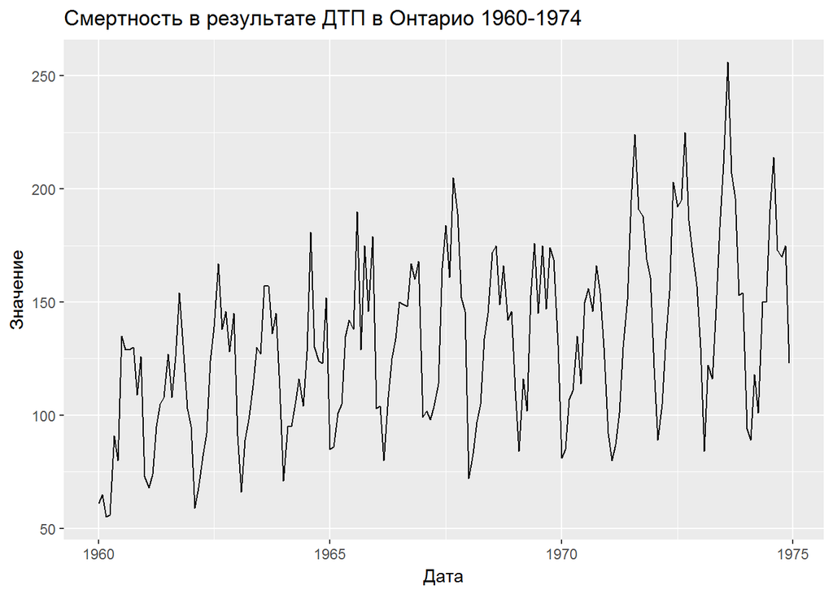

```r
autoplot(d) +
  labs (title = "Смертность в результате ДТП в Онтарио 1960-1974", y = "Значение", x = "Дата")
```

Данные безусловно являются временным рядом, поскольку наблюдения отмечены на равных промежутках времени (помесячно).

## Закономерные компоненты

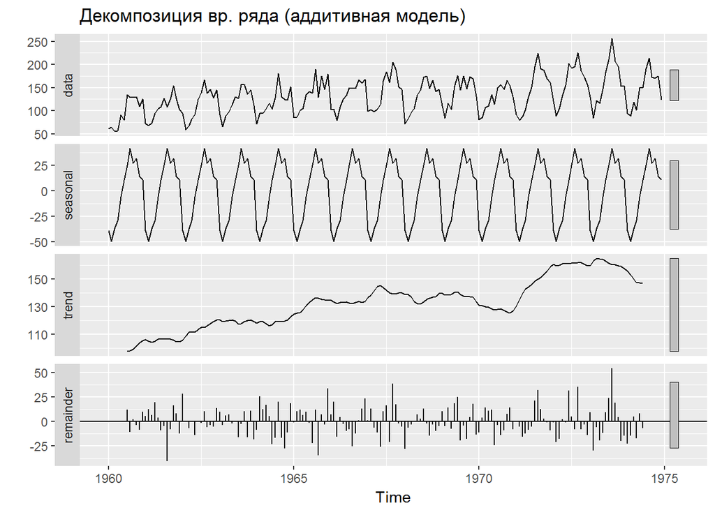

```r
decomp <- decompose(d, type = "additive")

autoplot(decomp) +
  labs (title = "Декомпозиция вр. ряда (аддитивная модель)")
```

Наложим тренд на исходную визуализацию.

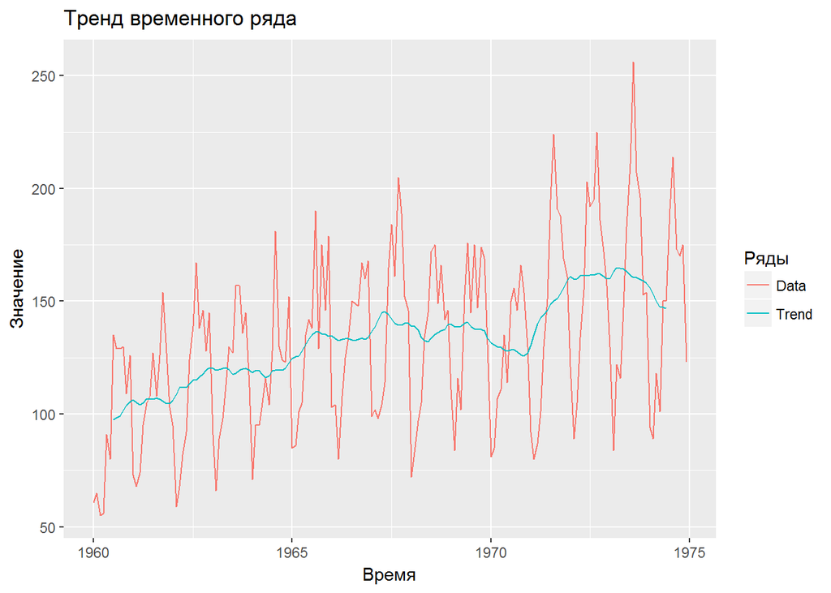

```r
autoplot(d, series = "Data") +
  autolayer(decomp$trend, series = "Trend") +
  labs(title = "Тренд временного ряда", color = "Ряды", y = "Значение", x = "Время")
```

Замечаем, что тренд имеет циклическую структуру, причем колебания тренда, как и колебания основного временного ряда, усиливаются со временем. Исходя из этого делаем предположение, что тренд имеет мультипликативную циклическую структуру, хоть и весьма слабо выраженную.

Общий рост ДТП в первую очередь связан с развитием автомобильного рынка и культуры использования личного автомобиля. Спады могут быть вызваны экономической обстановкой - снижение реальных доходов населения, снижение покупательской способности однозначно отражается на использовании автомобиля - от покупки до заправки и обслуживания.

### Сезонность

Ряд сезонный, аддитивного типа (колебания практически не изменяются вплоть до 1971 года, далее колебания резко увеличиваются, однако сохраняют свою амплитуду далее). Длина сезонного цикла составляет один год.

### Нетипичные наблюдения, пропуски, выбросы

Пропуски, а также выбросы, которые невозможно было бы объяснить случайной компонентой отсутствуют. Как уже было отмечено ранее, после 1971 ряд меняет свое поведение, однако все-таки продолжает сохранять общую тенденцию.

Корректировать временной ряд не требуется.

Для построения модели можно использовать весь временной ряд, поскольку резкий рост в упомянутом периоде отражен в тренде.

# Построение и выбор модели

Данный временной ряд лучше всего могут описать модели, учитывающие сезонность.

Построим модели разных типов на исторических данных.

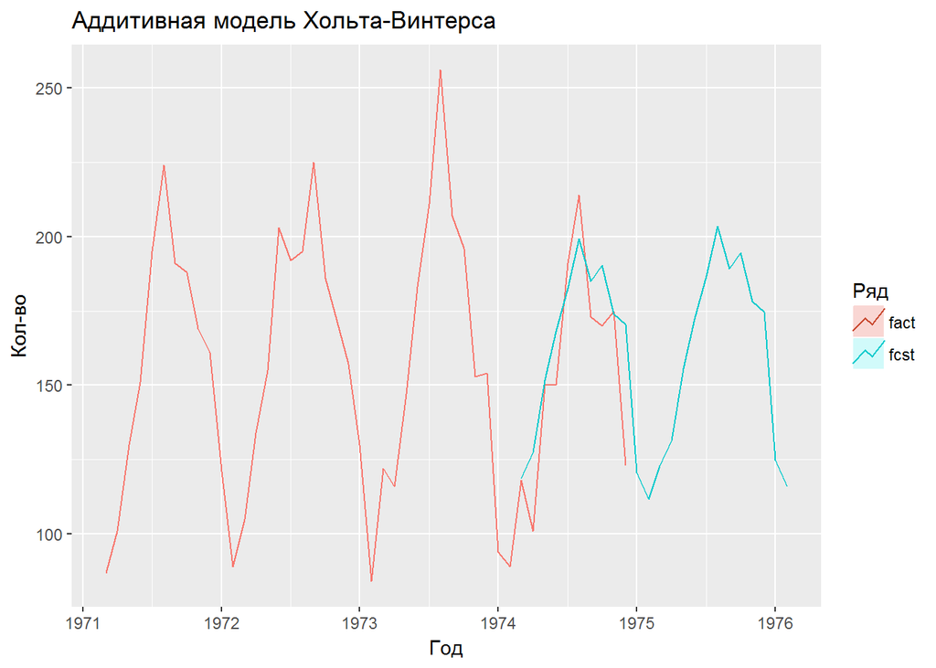

```r
dd <- window(d, start = 1971.1)
dt <- window(d, end = 1974.1)
da <- hw(dt, seasonal = "additive", h = 24)
autoplot(dd, series = "fact") +
  autolayer(da, series = "fcst", PI = F) +
  labs (title = "Аддитивная модель Хольта-Винтерса", y = "Кол-во", x = "Год", color = "Ряд")
```

Видим, что аддитивная модель в целом соблюдает движение временного ряда, однако не учитывает увеличившиеся колебания.

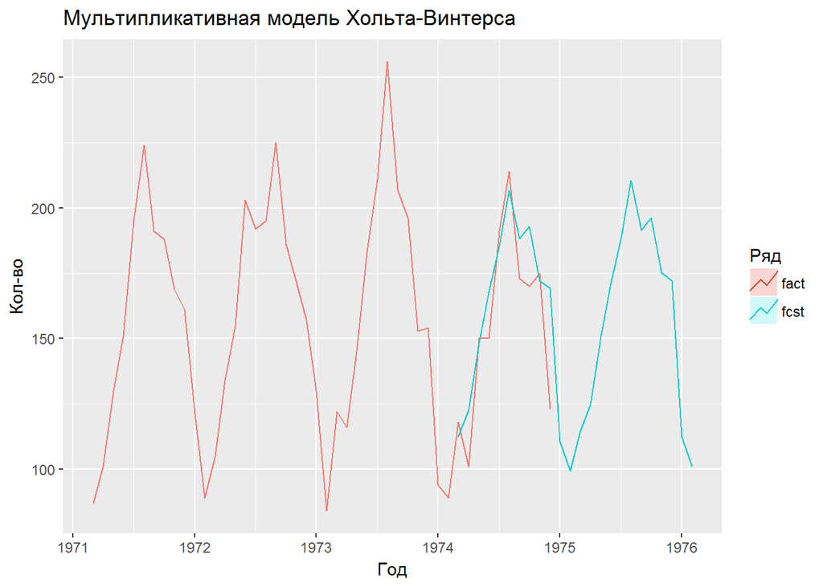

```r
dd1 <- window(d, start = 1971.1)
dt1 <- window(d, end = 1974.1)
da1 <- hw(dt1, seasonal = "multiplicative", h = 24)
autoplot(dd1, series = "fact") +
  autolayer(da1, series = "fcst", PI = F) +
  labs (title = "Мультипликативная модель Хольта-Винтерса", y = "Кол-во", x = "Год", color = "Ряд")
```

Мультипликативная модель гораздо ближе к фактическим данным, однако все еще не учитывает возросшие колебания. Попробуем отказаться от гипотезы о том, что допустимо использовать весь временной ряд и перестроим модели основываясь на данных с 1971 года.

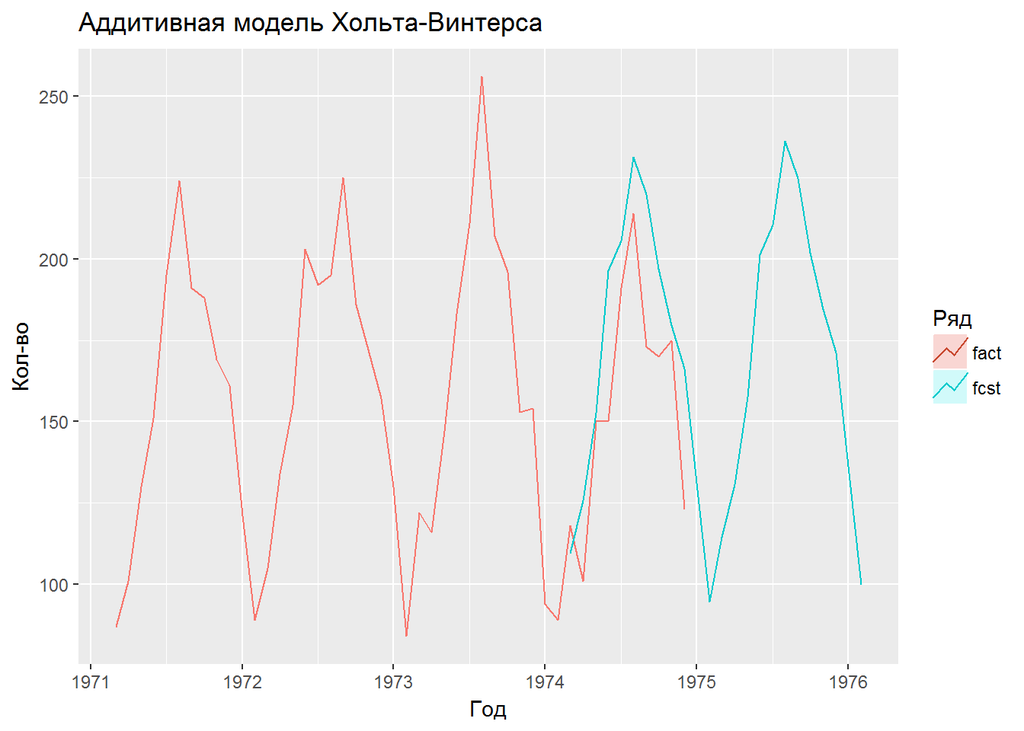

```r
dd <- window(d, start = 1971.1)
dt <- window(d, start = 1971.1, end = 1974.1)
da <- hw(dt, seasonal = "additive", h = 24)
autoplot(dd, series = "fact") +
  autolayer(da, series = "fcst", PI = F) +
  labs (title = "Аддитивная модель Хольта-Винтерса", y = "Кол-во", x = "Год", color = "Ряд")
```

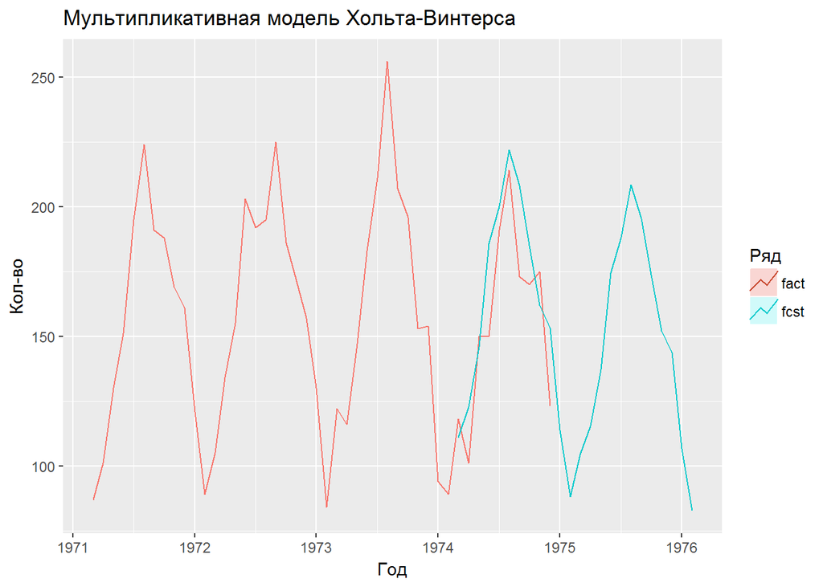

```r
dd1 <- window(d, start = 1971.1)
dt1 <- window(d, start = 1971.1, end = 1974.1)
da1 <- hw(dt1, seasonal = "multiplicative", h = 24)
autoplot(dd1, series = "fact") +
  autolayer(da1, series = "fcst", PI = F) +
  labs (title = "Мультипликативная модель Хольта-Винтерса", y = "Кол-во", x = "Год", color = "Ряд")
```

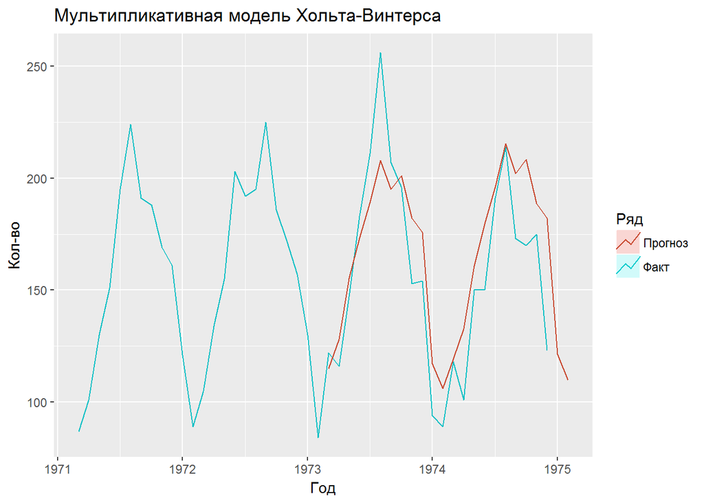

```r
exdl <- window(d, end = 1973.1)
exhwm <- hw(exdl, seasonal = "multiplicative", h = 24)

autoplot(dd1, series = "Факт") +
  autolayer(exhwm, series = "Прогноз", PI = F)+
  labs (title = "Мультипликативная модель Хольта-Винтерса", y = "Кол-во", x = "Год", color = "Ряд")
```

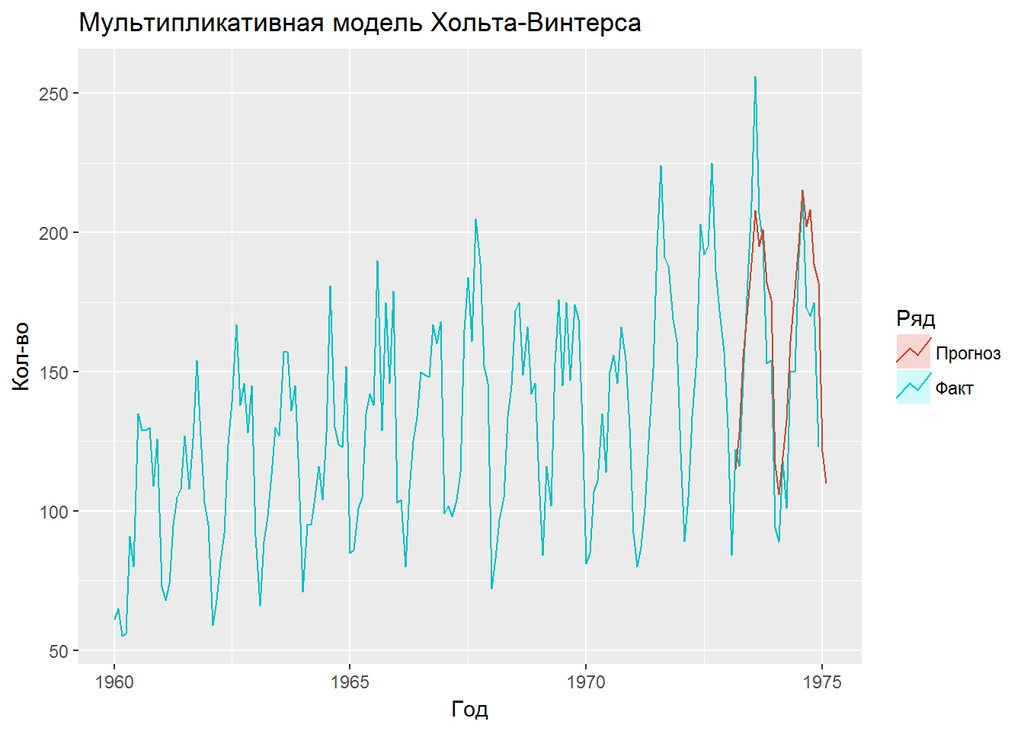

```r
autoplot(d, series = "Факт") +
  autolayer(exhwm, series = "Прогноз", PI = F) +
  labs (title = "Мультипликативная модель Хольта-Винтерса", y = "Кол-во", x = "Год", color = "Ряд")
```

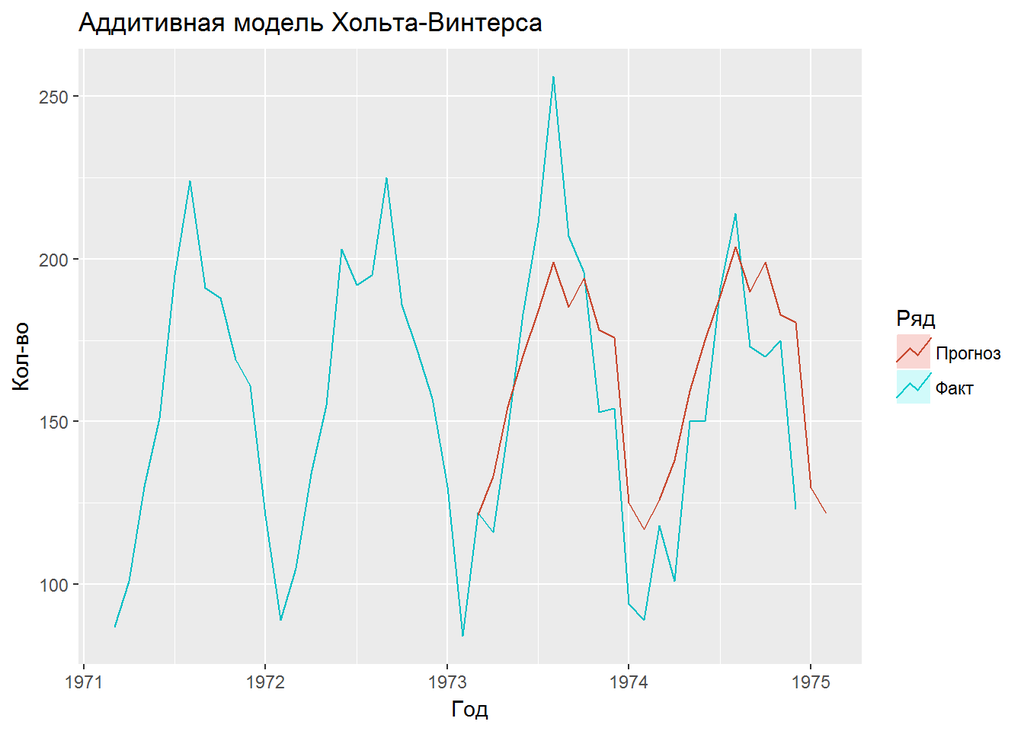

```r
exhwa <- hw(exdl, seasonal = "additive", h = 24)
autoplot(dd1, series = "Факт") +
  autolayer(exhwa, series = "Прогноз", PI = F) +
  labs (title = "Аддитивная модель Хольта-Винтерса", y = "Кол-во", x = "Год", color = "Ряд")
```

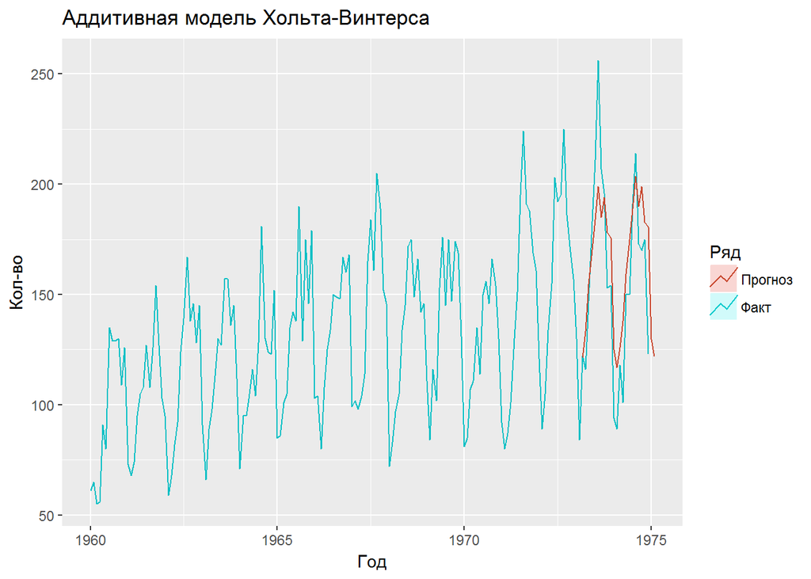

```r
autoplot(d, series = "Факт") +
  autolayer(exhwa, series = "Прогноз", PI = F) +
  labs (title = "Аддитивная модель Хольта-Винтерса", y = "Кол-во", x = "Год", color = "Ряд")
```

Сравнив две модели визуально, видим, что мультипликативная лучше подстроена под характер временного ряда. Проверим это утверждение с помощью исследования ошибок прогноза.

```r
rbind(accuracy(exhwa, d)[2,],
      accuracy(exhwm, d)[2,])%>%

  as_tibble() %>%
  round(2) %>%
  mutate(`Модель` = c('Аддитивная', "Мультипликативная")) %>%
  select(`Модель`, MASE, MAPE, everything()) %>%
  arrange(MASE)
```

```
## # A tibble: 2 x 9
##              Модель  MASE  MAPE     ME  RMSE   MAE   MPE  ACF1 `Theil's U`
##               <chr> <dbl> <dbl>  <dbl> <dbl> <dbl> <dbl> <dbl>       <dbl>
## 1 Мультипликативная  1.12 13.61 -10.81 24.76 19.78 -9.43  0.43        0.70
## 2        Аддитивная  1.17 14.54  -8.52 25.77 20.71 -9.06  0.47        0.76
```

Действительно, несмотря на то, что по некоторым ошибкам (например ME и MPE), мультипликативная модель уступает, в остальных случая эта модель более аккуратна, хотя и не имеет большого отрыва.

Проведем еще одно сравнение аккуратности с помощью метода скользящего контроля.

```r
RMSE <- function(errors) {
  errors^2 %>% mean(na.rm = T) %>% sqrt()
}
```

```r
dd_err <- tibble(horizon_mult = 1:24) %>%
   mutate(error_mult = map_dbl(horizon_mult,
                         function(x) tsCV(dd, hw, seasonal = "multiplicative", h = x) %>% RMSE()))

head(dd_err)
```

```
## # A tibble: 6 x 2
##   horizon_mult error_mult
##          <int>      <dbl>
## 1            1      23.39
## 2            2      30.25
## 3            3      38.79
## 4            4      58.01
## 5            5      74.43
## 6            6      87.84
```

```r
d_err <- tibble(horizon_add = 1:24) %>%
   mutate(error_add = map_dbl(horizon_add,
                         function(x) tsCV(dd, hw, seasonal = "additive", h = x) %>% RMSE()))
head(d_err)
```

```
## # A tibble: 6 x 2
##   horizon_add error_add
##         <int>     <dbl>
## 1           1     22.95
## 2           2     30.00
## 3           3     39.00
## 4           4     58.12
## 5           5     74.23
## 6           6     87.72
```

```r
cbind(dd_err, d_err)  %>%

  as_tibble() %>%
  round(2) %>% head()
```

```
## # A tibble: 6 x 4
##   horizon_mult error_mult horizon_add error_add
##          <dbl>      <dbl>       <dbl>     <dbl>
## 1            1      23.39           1     22.95
## 2            2      30.25           2     30.00
## 3            3      38.79           3     39.00
## 4            4      58.01           4     58.12
## 5            5      74.43           5     74.23
## 6            6      87.84           6     87.72
```

# Разработка прогноза

Строим модель:

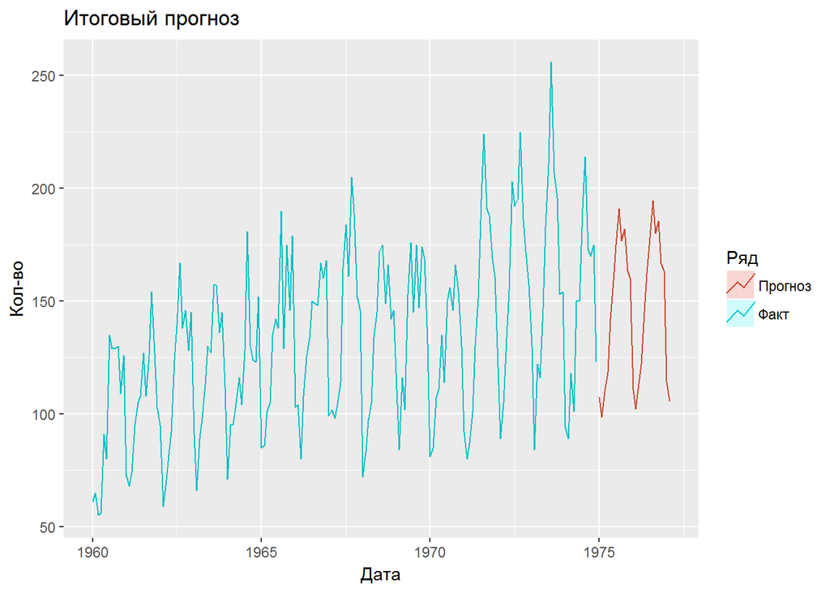

```r
fcst <- hw(d, sesonal = "multiplicative", h = 26)

autoplot(d, series = "Факт") +
  autolayer(fcst, PI = F, series = "Прогноз") +
  labs (title = "Итоговый прогноз", x = "Дата", y = "Кол-во", color = "Ряд")
```

В основу прогноза заложены следующие предположения:

1. Поведение тренда сохранится на горизонте прогнозирования
2. Резкие колебания в 1971-1974 гг. вызваны случайными причинами и не являются новым характером поведения временного ряда.

Для разработки прогноза использованы сезонность и тренд. На мой взгляд, сезонность сохранится полностью, а тренд сохранится еще некоторое время, а затем резкой пойдет вверх в связи с резким увеличением количества личного транспорта на стыке веков.

Данный прогноз в корректировке не нуждается, прогнозу доверяю.